# BAM files and alignments

Michael Hunt

April 8, 2016

### Setup and BAM header metadata

All of the problems in this problem set will work with the HNRNPC knockdown BAM files.

```r
library(RNAseqData.HNRNPC.bam.chr14)
bf = RNAseqData.HNRNPC.bam.chr14_BAMFILES
length(bf)
```

```
## [1] 8
```

```r
library(GenomicFiles)
bff = GenomicFiles(files=bf)
library(Homo.sapiens)
seqinfo(bff) = seqinfo(Homo.sapiens)
bff
```

```
## GenomicFiles object with 0 ranges and 8 files:
## files: ERR127306_chr14.bam, ERR127307_chr14.bam, ..., ERR127304_chr14.bam, ERR127305_chr14.bam
## detail: use files(), rowRanges(), colData(), ...
```

```r
library(Rsamtools)
bfl = BamFileList(file=bf)
bfl
```

```
## BamFileList of length 8
## names(8): ERR127306 ERR127307 ERR127308 ... ERR127303 ERR127304 ERR127305
```

```r
seqinfo(bfl)
```

```
## Seqinfo object with 93 sequences from an unspecified genome:
##   seqnames              seqlengths isCircular genome
##   chr1                   249250621       <NA>   <NA>
##   chr10                  135534747       <NA>   <NA>
##   chr11                  135006516       <NA>   <NA>
##   chr11_gl000202_random      40103       <NA>   <NA>
##   chr12                  133851895       <NA>   <NA>
##   ...                          ...        ...    ...
##   chrUn_gl000247             36422       <NA>   <NA>
##   chrUn_gl000248             39786       <NA>   <NA>
##   chrUn_gl000249             38502       <NA>   <NA>
##   chrX                   155270560       <NA>   <NA>
##   chrY                    59373566       <NA>   <NA>
```

ScanBamHeader from the Rsamtools package helps to obtain metadata about a BAM file.

```r
library(Rsamtools)
h1 = scanBamHeader(files(bff)[1])[[1]]
```

`names(h1)` shows elements, targets and text. You can use h1$text$'@PG’ to determine information about the program that generated the BAM file.

What was the version of `tophat` used to generate the BAM file? Look for `VN tag in the text component.

```r
str(h1)
```

```
## List of 2
##  $ targets: Named int [1:93] 249250621 135534747 135006516 40103 133851895 115169878 107349540 102531392 90354753 81195210 ...
##   ..- attr(*, "names")= chr [1:93] "chr1" "chr10" "chr11" "chr11_gl000202_random" ...
##  $ text   :List of 95
##   ..$ @HD: chr [1:2] "VN:1.0" "SO:coordinate"
##   ..$ @SQ: chr [1:2] "SN:chr1" "LN:249250621"
##   ..$ @SQ: chr [1:2] "SN:chr10" "LN:135534747"
##   ..$ @SQ: chr [1:2] "SN:chr11" "LN:135006516"
##   ..$ @SQ: chr [1:2] "SN:chr11_gl000202_random" "LN:40103"
##   ..$ @SQ: chr [1:2] "SN:chr12" "LN:133851895"
##   ..$ @SQ: chr [1:2] "SN:chr13" "LN:115169878"
##   ..$ @SQ: chr [1:2] "SN:chr14" "LN:107349540"
##   ..$ @SQ: chr [1:2] "SN:chr15" "LN:102531392"
##   ..$ @SQ: chr [1:2] "SN:chr16" "LN:90354753"
##   ..$ @SQ: chr [1:2] "SN:chr17" "LN:81195210"
##   ..$ @SQ: chr [1:2] "SN:chr17_ctg5_hap1" "LN:1680828"
##   ..$ @SQ: chr [1:2] "SN:chr17_gl000203_random" "LN:37498"
##   ..$ @SQ: chr [1:2] "SN:chr17_gl000204_random" "LN:81310"
##   ..$ @SQ: chr [1:2] "SN:chr17_gl000205_random" "LN:174588"
##   ..$ @SQ: chr [1:2] "SN:chr17_gl000206_random" "LN:41001"
##   ..$ @SQ: chr [1:2] "SN:chr18" "LN:78077248"
##   ..$ @SQ: chr [1:2] "SN:chr18_gl000207_random" "LN:4262"
##   ..$ @SQ: chr [1:2] "SN:chr19" "LN:59128983"
##   ..$ @SQ: chr [1:2] "SN:chr19_gl000208_random" "LN:92689"
##   ..$ @SQ: chr [1:2] "SN:chr19_gl000209_random" "LN:159169"
##   ..$ @SQ: chr [1:2] "SN:chr1_gl000191_random" "LN:106433"
##   ..$ @SQ: chr [1:2] "SN:chr1_gl000192_random" "LN:547496"
##   ..$ @SQ: chr [1:2] "SN:chr2" "LN:243199373"
##   ..$ @SQ: chr [1:2] "SN:chr20" "LN:63025520"
##   ..$ @SQ: chr [1:2] "SN:chr21" "LN:48129895"
##   ..$ @SQ: chr [1:2] "SN:chr21_gl000210_random" "LN:27682"
##   ..$ @SQ: chr [1:2] "SN:chr22" "LN:51304566"
##   ..$ @SQ: chr [1:2] "SN:chr3" "LN:198022430"
##   ..$ @SQ: chr [1:2] "SN:chr4" "LN:191154276"
##   ..$ @SQ: chr [1:2] "SN:chr4_ctg9_hap1" "LN:590426"
##   ..$ @SQ: chr [1:2] "SN:chr4_gl000193_random" "LN:189789"
##   ..$ @SQ: chr [1:2] "SN:chr4_gl000194_random" "LN:191469"
##   ..$ @SQ: chr [1:2] "SN:chr5" "LN:180915260"
##   ..$ @SQ: chr [1:2] "SN:chr6" "LN:171115067"
##   ..$ @SQ: chr [1:2] "SN:chr6_apd_hap1" "LN:4622290"
```

[output cut: 44 more lines]

```
##   ..$ @SQ: chr [1:2] "SN:chrUn_gl000238" "LN:39939"
##   ..$ @SQ: chr [1:2] "SN:chrUn_gl000239" "LN:33824"
##   ..$ @SQ: chr [1:2] "SN:chrUn_gl000240" "LN:41933"
##   ..$ @SQ: chr [1:2] "SN:chrUn_gl000241" "LN:42152"
##   ..$ @SQ: chr [1:2] "SN:chrUn_gl000242" "LN:43523"
##   ..$ @SQ: chr [1:2] "SN:chrUn_gl000243" "LN:43341"
##   ..$ @SQ: chr [1:2] "SN:chrUn_gl000244" "LN:39929"
##   ..$ @SQ: chr [1:2] "SN:chrUn_gl000245" "LN:36651"
##   ..$ @SQ: chr [1:2] "SN:chrUn_gl000246" "LN:38154"
##   ..$ @SQ: chr [1:2] "SN:chrUn_gl000247" "LN:36422"
##   ..$ @SQ: chr [1:2] "SN:chrUn_gl000248" "LN:39786"
##   ..$ @SQ: chr [1:2] "SN:chrUn_gl000249" "LN:38502"
##   ..$ @SQ: chr [1:2] "SN:chrX" "LN:155270560"
##   ..$ @SQ: chr [1:2] "SN:chrY" "LN:59373566"
##   ..$ @PG: chr [1:3] "ID:TopHat" "VN:2.0.8b" "CL:/home/hpages/tophat-2.0.8b.Linux_x86_64/tophat --mate-inner-dist 150 --solexa-quals --max-multihits 5 --no-discordant --no-m"| __truncated__
```

```r
str(h1$text)
```

```
## List of 95
##  $ @HD: chr [1:2] "VN:1.0" "SO:coordinate"
##  $ @SQ: chr [1:2] "SN:chr1" "LN:249250621"
##  $ @SQ: chr [1:2] "SN:chr10" "LN:135534747"
##  $ @SQ: chr [1:2] "SN:chr11" "LN:135006516"
##  $ @SQ: chr [1:2] "SN:chr11_gl000202_random" "LN:40103"
##  $ @SQ: chr [1:2] "SN:chr12" "LN:133851895"
##  $ @SQ: chr [1:2] "SN:chr13" "LN:115169878"
##  $ @SQ: chr [1:2] "SN:chr14" "LN:107349540"
##  $ @SQ: chr [1:2] "SN:chr15" "LN:102531392"
##  $ @SQ: chr [1:2] "SN:chr16" "LN:90354753"
##  $ @SQ: chr [1:2] "SN:chr17" "LN:81195210"
##  $ @SQ: chr [1:2] "SN:chr17_ctg5_hap1" "LN:1680828"
##  $ @SQ: chr [1:2] "SN:chr17_gl000203_random" "LN:37498"
##  $ @SQ: chr [1:2] "SN:chr17_gl000204_random" "LN:81310"
```

[output cut: 81 more lines]

```r
h1$text$"@PG"
```

```
## [1] "ID:TopHat"
## [2] "VN:2.0.8b"
## [3] "CL:/home/hpages/tophat-2.0.8b.Linux_x86_64/tophat --mate-inner-dist 150 --solexa-quals --max-multihits 5 --no-discordant --no-mixed --coverage-search --microexon-search --library-type fr-unstranded --num-threads 2 --output-dir tophat2_out/ERR127306 /home/hpages/bowtie2-2.1.0/indexes/hg19 fas…
```

```r
h1$text$"@PG"[2]
```

```
## [1] "VN:2.0.8b"
```

### countBam and read length determination

The `countBam` utility helps to determine record volume.

```r
c1 = countBam( files(bff)[1] )
c1
```

```
##   space start end width                file records nucleotides
## 1    NA    NA  NA    NA ERR127306_chr14.bam  800484    57634848
```

Use arithmetic on the elements of c1 above to determine the read length of the HNRNPC sequencing runs.

```r
c1$nucleotides/c1$records
```

```
## [1] 72
```

### ScanBamParam to control BAM processing

The ‘which’ component of the ScanBamParam object can hold a GRanges to identify regions of interest in a query to a BAM file.

```r
myr = GRanges("chr14", IRanges(1, 20e6))
par = ScanBamParam(which=myr)
c2 = countBam(files(bff)[1], param=par)
c2
```

```
##   space start      end    width                file records nucleotides
## 1 chr14     1 20000000 20000000 ERR127306_chr14.bam    6183      445176
```

### Distribution of insert sizes for paired-end reads

We can request that scanBam return details of alignments, such as positions of primary and mate reads, and the insert size.

```r
p = ScanBamParam(which=GRanges("chr14", IRanges(20e6, 25e6)),
  what=c("pos", "mpos", "isize"))
sc2 = scanBam(files(bff)[1], param=p)
```

Visualize the distribution of signed insert sizes after trimming away outliers with

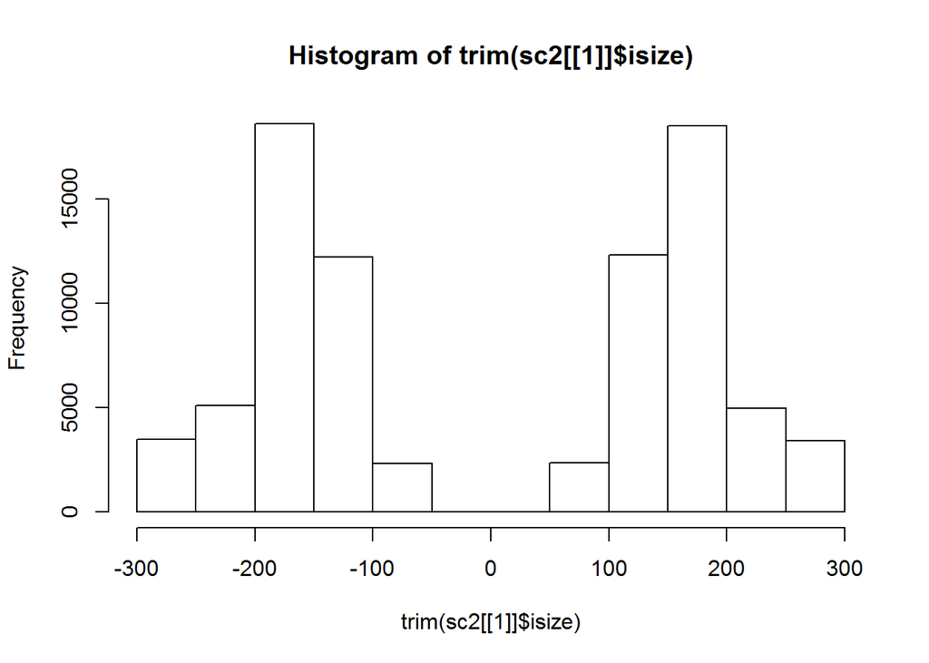

```r
trim = function(x, maxabs=300) x[abs(x)<maxabs]
hist(trim(sc2[[1]]$isize))
```

Confining attention to reads aligned to the positive strand, what is the median insert size?

```r
str(sc2)
```

```
## List of 1
##  $ chr14:20000000-25000000:List of 3
##   ..$ pos  : int [1:138223] 20098354 20098356 20098365 20098369 20098438 20098443 20098443 20098444 20137133 20137181 ...
##   ..$ mpos : int [1:138223] 20098443 20098438 20098444 20098443 20098356 20098369 20098354 20098365 20137181 20137133 ...
##   ..$ isize: int [1:138223] 161 154 151 146 -154 -146 -161 -151 120 -120 ...
```

```r
a<-sc2[[1]]$isize
median(a[a>0])
```

```
## [1] 207
```

### Called base frequencies by sequencing cycle (position in read)

The `readGAlignments` function will return the nucleotide sequences for reads.

```r
library(GenomicAlignments)
r1 = readGAlignments( files(bff)[1], param=ScanBamParam(what=c("seq", "mapq", "qual")))
```

The following function will compute relative frequencies of bases by position:

```r
btab = function(dss, pos) {
  tmp = table(substr(dss, pos, pos))[c("A", "C", "G", "T")]
  tmp/sum(tmp)
}
```

Apply `btab` to `mcols(r1)$seq`.

Which gives the sequence of relative frequencies of nucleotide “C” in positions 1,2,3,4?

```r
sapply(1:4, function(x) btab(mcols(r1)$seq, x))
```

```
##        [,1]      [,2]      [,3]      [,4]
## A 0.1677556 0.2347469 0.2391716 0.2583524
## C 0.4094274 0.2454081 0.2544935 0.2553480
## G 0.1900511 0.2858139 0.3032503 0.2988405
## T 0.2327658 0.2340311 0.2030846 0.1874591
```

### Scalable genomic iteration: the yieldSize parameter

We can use the `BamFile` class directly to mediate queries to reads. To traverse the reads sequentially in chunks of a specified size, set the `yieldSize` parameter, and use `open()` to activate the sequential reading procedure. For example, in the following, each successive call to `readGAlignments` delivers 50000 records, up to the end of the file. The last chunk may have fewer records, and after all records have been retrieved, calls will return `NULL`.

```r
bf1 = BamFile(bf[1], yieldSize=50000)
open(bf1)
ry1 = readGAlignments(bf1, param=ScanBamParam(what="seq"))
ry2 = readGAlignments(bf1, param=ScanBamParam(what="seq"))
head(ry2[1])
```

```
## GAlignments object with 1 alignment and 1 metadata column:
##       seqnames strand       cigar    qwidth     start       end     width
##          <Rle>  <Rle> <character> <integer> <integer> <integer> <integer>
##   [1]    chr14      -  51M179N21M        72  23239784  23240034       251
##           njunc |
##       <integer> |
##   [1]         1 |
##                                                                            seq
##                                                                 <DNAStringSet>
##   [1] ATCTACACATTACCACTGGCAGTCACTGCTACAATGTGGGCTGTTCTTGAGCTAGGTGCTGAGACAGGTGTG
##   -------
##   seqinfo: 93 sequences from an unspecified genome
```

What is the start position of the first read in ry2 as computed above?

```r
head(ry2[1])
```

```
## GAlignments object with 1 alignment and 1 metadata column:
##       seqnames strand       cigar    qwidth     start       end     width
##          <Rle>  <Rle> <character> <integer> <integer> <integer> <integer>
##   [1]    chr14      -  51M179N21M        72  23239784  23240034       251
##           njunc |
##       <integer> |
##   [1]         1 |
##                                                                            seq
##                                                                 <DNAStringSet>
##   [1] ATCTACACATTACCACTGGCAGTCACTGCTACAATGTGGGCTGTTCTTGAGCTAGGTGCTGAGACAGGTGTG
##   -------
##   seqinfo: 93 sequences from an unspecified genome
```

### Decay of base call quality in later cycles

In the following

```r
library(GenomicAlignments)
r1 = readGAlignments( files(bff)[1], param=ScanBamParam(what=c("seq", "mapq", "qual")))
```

r1 includes information on base-call quality, encoded:

```r
r1q = mcols(r1)$qual
r1q[1:3]
```

```
##   A PhredQuality instance of length 3
##     width seq
## [1]    72 ++)+*++++++&+++++++++++*++++++'...%(+++++*+++(+&#++++++&++&$&)$!"
## [2]    72 +++++++++++++++++++++++++)+++)+...+)++*)++++++++++****++*+++**+*)
## [3]    72 %*****&&&&%%%))****************...******))'&)))))'(********)*****
```

Focus attention on reads aligning to the + strand and use the coercion to matrix to obtain ordered values in [0,10] measuring base call quality.

We’ll check just the first 2000 reads.

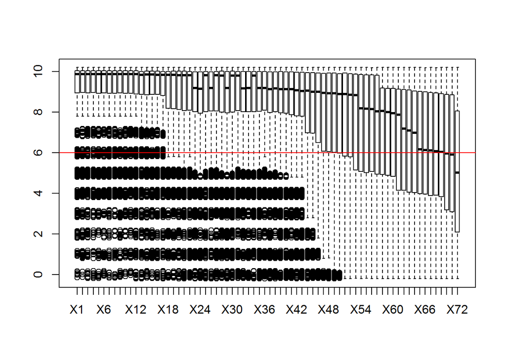

```r
r1q = mcols(r1[strand(r1)=="+"])$qual
r1qm = as(r1q,"matrix")
dd = data.frame(jitter(r1qm[1:2000,]))
boxplot(dd)
abline(h=6,col="red")
```

At what cycle has the median quality score dipped below 6?